# PCA and Clustering on Breast Cancer Data

Chloé Winters

2025-11-13

# 1 Introduction

This assignment will look at breast cancer data. First it will start with going throuugh the exploratory data analysis for this data set. Following that, PCA and Clustering methodolgy to analyse the data.

# 2 Materials

## 2.1 Data Set

According to the World Health Organization (WHO) breast cancer is one of the most common cancers for women worldwide, and is the second leading cause of cancer related deaths in women. This makes identifying breast cancer in women so important because the sooner you start treating a patient the better.

```r
url ="https://chloewinters79.github.io/STA551/Data/syntheticBreastCancerData.csv"
cancer = read.csv(url, header = TRUE)
```

The data set being used for this assignment is a synthetic breast cancer data set, there are 600 observations in the data set and it consists of 11 variables, 10 of them are numerical and 1 of them is categorical. The 11 variables are detailed below,

1. Sample_No: (num) unique identifier
2. Thickness_of_Clump: (num) Benign cells are more likely monolayers and malignant or cancerous cells are multilayer
3. Cell_Size_Uniformity: (num) Benign cells does not vary in size and malignant or cancer cell vary in size
4. Cell_Shape_Uniformity: (num) Benign cells do not vary in shape, while malignant or cancerous cells vary in shape
5. Marginal_Adhesion: (num) Benign cells are more likely to stick together, while malignant or cancerous cells are loose or do not stick together
6. Single_Epithelial_Cell_Size: (num) In benign cases epithelial cells are normal in size, while in malignant or cancerous cases they are significantly enlarged
7. Bare_Nuclei: (num) In benign cases the bare nuclei are not surrounded by cytoplasm, while in malignant or cancerous cases they are surrounded by cytoplasm
8. Bland_Chromatin: (num) Benign cells have uniform or fine chromatin, while malignant or cancerous cells have coarse chromatin
9. Normal_Nucleoli: (num) In benign cases nucleoli are very small, while in malignant or cancerous cases nucleoli are more prominent
10. Mitoses: (num) In benign cases cell growth is normal, while in malignant or cancerous cases there is abnormal cell growth
11. Outcome: (cat) “No” denotes benign breast cancer, “Yes” denotes malignant breast cancer

It should be noted that while numeric, variables 2 - 10 are integers from 1-10.

## 2.2 Expoloratory Data Analysis

First we are going to look at the summary information of the data set. Looking at the variables most of their means seem to be in the 3-5 range, with Mitoses having the lowest mean at 2.093, and Thickness_of_Clump having the largest mean at 5.41. There does seem to be some indication of right skewness with a majority of the variables, however, we will wait to look at some visual representation before making any final conclusions. A table for the categorical variable outcome was also created, there are 380 No observations, which are observations where the cancer was benign and 220 Yes observations, where the cancer was malignant. While this is not a 50/50 split, it is almost a 60/40 split, which is not skewed heavily enough in either direction that there seems to be any cause for cancer at this point.

```r
summary(cancer)
```

```
   Sample_No     Thickness_of_Clump Cell_Size_Uniformity Cell_Shape_Uniformity
 Min.   :  1.0   Min.   : 1.00      Min.   : 1.000       Min.   : 1.000
 1st Qu.:150.8   1st Qu.: 3.00      1st Qu.: 2.000       1st Qu.: 2.000
 Median :300.5   Median : 5.00      Median : 3.000       Median : 3.000
 Mean   :300.5   Mean   : 5.41      Mean   : 4.122       Mean   : 4.195
 3rd Qu.:450.2   3rd Qu.: 7.25      3rd Qu.: 6.000       3rd Qu.: 6.000
 Max.   :600.0   Max.   :10.00      Max.   :10.000       Max.   :10.000
 Marginal_Adhesion Single_Epithelial_Cell_Size  Bare_Nuclei   Bland_Chromatin
 Min.   : 1.000    Min.   : 1.000              Min.   : 1.0   Min.   : 1.000
 1st Qu.: 2.000    1st Qu.: 3.000              1st Qu.: 2.0   1st Qu.: 3.000
 Median : 3.000    Median : 4.000              Median : 3.0   Median : 4.000
 Mean   : 3.763    Mean   : 4.293              Mean   : 4.5   Mean   : 4.495
 3rd Qu.: 5.000    3rd Qu.: 5.000              3rd Qu.: 9.0   3rd Qu.: 6.000
 Max.   :10.000    Max.   :10.000              Max.   :10.0   Max.   :10.000
 Normal_Nucleoli     Mitoses         Outcome
 Min.   : 1.000   Min.   : 1.000   Length:600
 1st Qu.: 2.000   1st Qu.: 1.000   Class :character
 Median : 3.000   Median : 2.000   Mode  :character
 Mean   : 3.812   Mean   : 2.093
 3rd Qu.: 5.000   3rd Qu.: 2.000
 Max.   :10.000   Max.   :10.000
```

```r
table(cancer$Outcome)
```

```
 No Yes
380 220
```

Moving onto a visual analysis of the variables, histograms were created for the following variables, Thickness_of_Clump, Cell_Size_Uniformity, Cell_Shape_Uniformity, Marginal_Adhesion, Single_Epithelial_Cell_Size, Bare_Nuclei, Bland_Chromatin, Normal_Nucleoli, and Mitosis. Looking at the output none of the variables appear to have a normal distribution. With the exception of the Thickness_of_Clump variable having a potential uniform distribution, all the other variables have a right skewness, with the variable Mitoses having the most severe skewness. The variables Normal_Nucleoli, Bare_Nuclei, Cell_Shape_Uniformity, Cell_Size_Uniformity, and Marginal_Adhesions having slightly less severe right skewness than Mitosis, but more severe than Single_Epithelial_Cell_Size and Bland_Chromatin, which while the least severe, are still clearly exhibiting a right skewness.

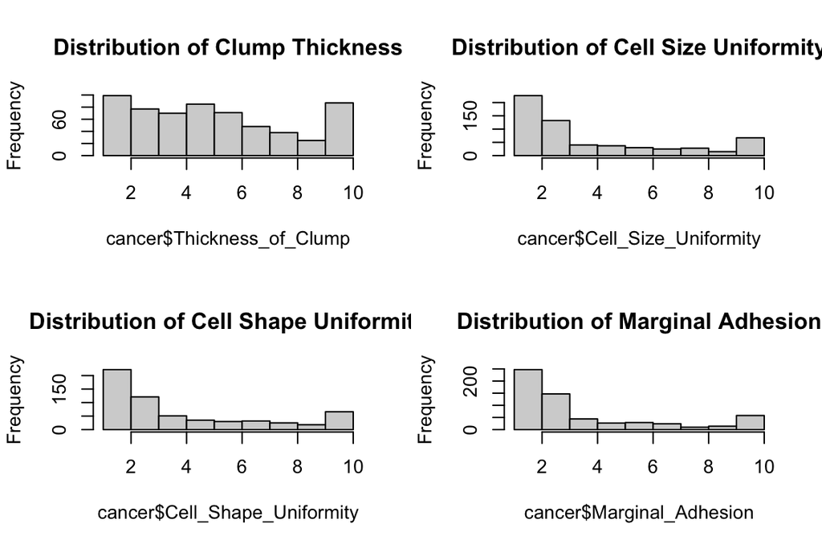

```r
par(mfrow = c(2,2))

hist(cancer$Thickness_of_Clump, main = "Distribution of Clump Thickness")
hist(cancer$Cell_Size_Uniformity, main = "Distribution of Cell Size Uniformity")
hist(cancer$Cell_Shape_Uniformity, main = "Distribution of Cell Shape Uniformity")

hist(cancer$Marginal_Adhesion, main = "Distribution of Marginal Adhesion")
```

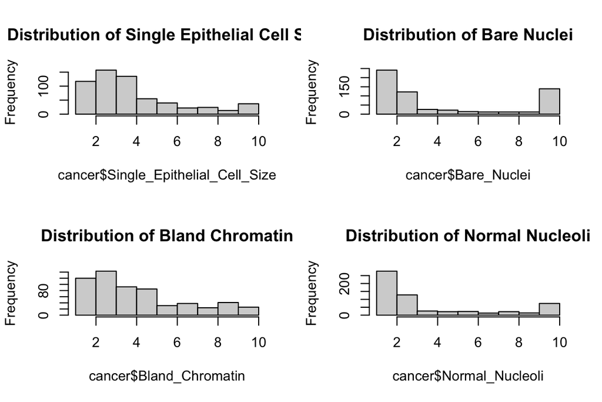

```r
hist(cancer$Single_Epithelial_Cell_Size, main = "Distribution of Single Epithelial Cell Size")
hist(cancer$Bare_Nuclei, main = "Distribution of Bare Nuclei")

hist(cancer$Bland_Chromatin, main = "Distribution of Bland Chromatin")
hist(cancer$Normal_Nucleoli, main = "Distribution of Normal Nucleoli")
```

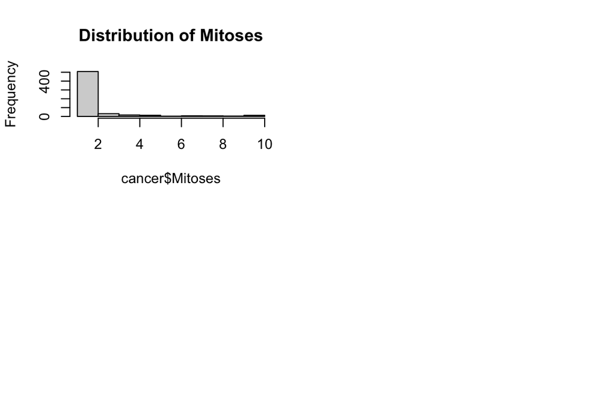

```r
hist(cancer$Mitoses, main = "Distribution of Mitoses")
```

Next box plots were created to look at the relationship between the numerical variables and the outcome variable. Looking at the output it appears that for all the variables the “No” outcome was consistent with the right skewness seen in the histograms above. When looking at the output for all the variables with the “Yes” outcome with the exception of the Mitoses variable all the “Yes” outcomes are showing a left skewness, the Mitoses variable shows right skewness. None of the boxplots show a normal distribution, all boxplots show either right or left skewness.

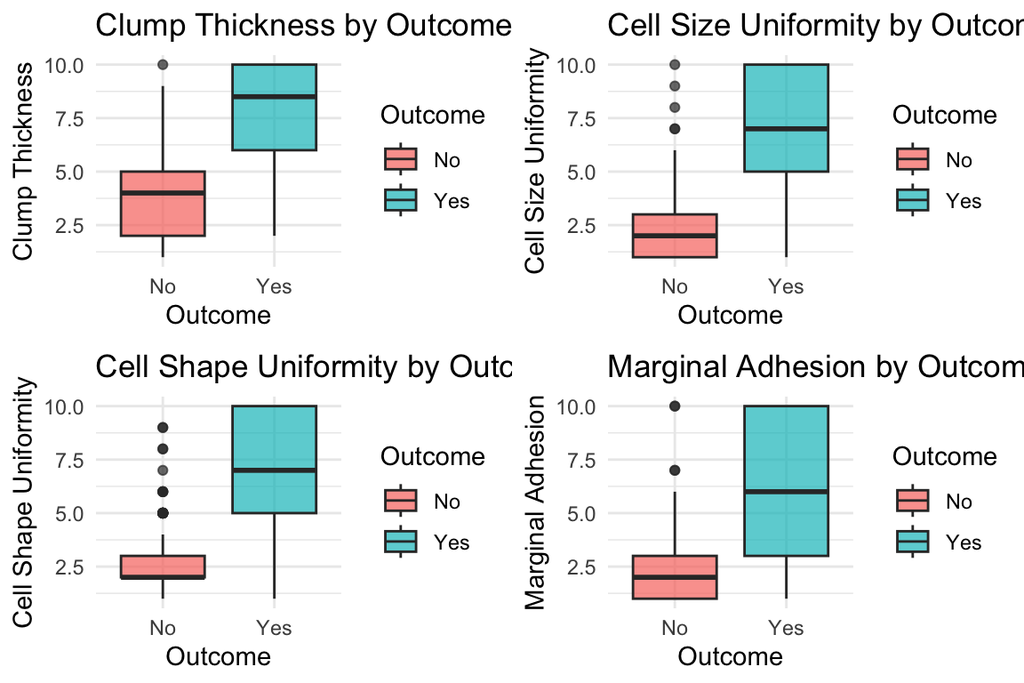

```r
# Make individual plots
p1 <- ggplot(cancer, aes(x = Outcome, y = Thickness_of_Clump, fill = Outcome)) +
  geom_boxplot(alpha = 0.7) +
  labs(title = "Clump Thickness by Outcome", y = "Clump Thickness") +
  theme_minimal()

p2 <- ggplot(cancer, aes(x = Outcome, y = Cell_Size_Uniformity, fill = Outcome)) +
  geom_boxplot(alpha = 0.7) +
  labs(title = "Cell Size Uniformity by Outcome", y = "Cell Size Uniformity") +
  theme_minimal()

p3 <- ggplot(cancer, aes(x = Outcome, y = Cell_Shape_Uniformity, fill = Outcome)) +
  geom_boxplot(alpha = 0.7) +
  labs(title = "Cell Shape Uniformity by Outcome", y = "Cell Shape Uniformity") +
  theme_minimal()

p4 <- ggplot(cancer, aes(x = Outcome, y = Marginal_Adhesion, fill = Outcome)) +
  geom_boxplot(alpha = 0.7) +
  labs(title = "Marginal Adhesion by Outcome", y = "Marginal Adhesion") +
  theme_minimal()

p5 <- ggplot(cancer, aes(x = Outcome, y = Single_Epithelial_Cell_Size, fill = Outcome)) +
  geom_boxplot(alpha = 0.7) +
  labs(title = "Single Epithelial Cell Size by Outcome", y = "Single Epithelial Cell Size") +
  theme_minimal()

p6 <- ggplot(cancer, aes(x = Outcome, y = Bare_Nuclei, fill = Outcome)) +
  geom_boxplot(alpha = 0.7) +
  labs(title = "Bare Nuclei by Outcome", y = "Bare Nuclei") +
  theme_minimal()

p7 <- ggplot(cancer, aes(x = Outcome, y = Bland_Chromatin, fill = Outcome)) +
  geom_boxplot(alpha = 0.7) +
  labs(title = "Bland Chromatin by Outcome", y = "Bland Chromatin") +
  theme_minimal()

p8 <- ggplot(cancer, aes(x = Outcome, y = Normal_Nucleoli, fill = Outcome)) +
  geom_boxplot(alpha = 0.7) +
  labs(title = "Normal Nucleoli by Outcome", y = "Normal Nucleoli") +
  theme_minimal()

p9 <- ggplot(cancer, aes(x = Outcome, y = Mitoses, fill = Outcome)) +
  geom_boxplot(alpha = 0.7) +
  labs(title = "Mitoses by Outcome", y = "Mitoses") +
  theme_minimal()

# Arrange into pages (2x2 layout per page)
grid.arrange(p1, p2, p3, p4, ncol = 2)   # Page 1
```

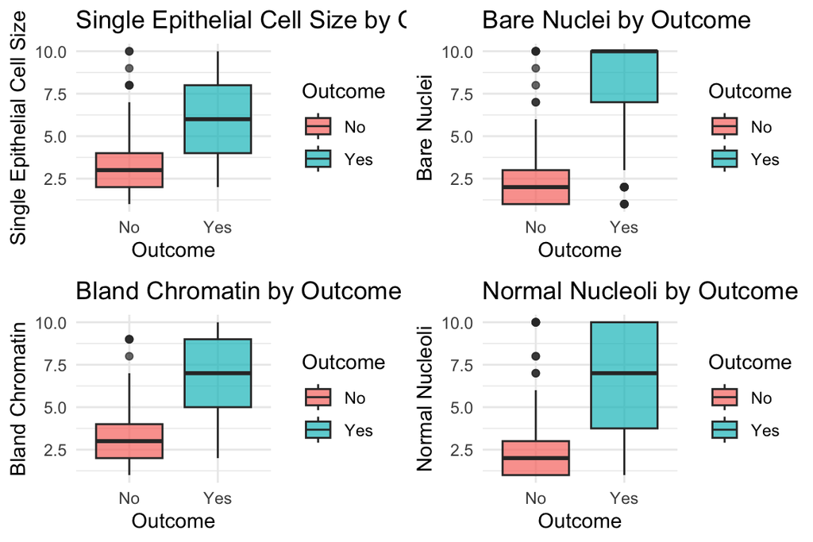

```r
grid.arrange(p5, p6, p7, p8, ncol = 2)   # Page 2
```

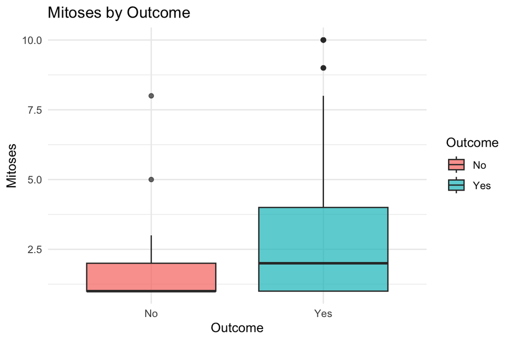

```r
grid.arrange(p9, ncol = 1)               # Page 3
```

Considering that all the numerical variables are integers between 1-10 a traditional pairwise graph does not make sense because it would be quite cluttered and correlation is harder to determine in those kinds of plots when the data is not continuous. To ensure we are still able to look at the correlation between variables, it made sense to do a correlation heat map to analyze the relationship between the numerical variables. Cell_Size_Uniformity and Cell_Shape_Uniformity are the most highly correlated variables with a correlation of 0.84, which is considered a strong correlation. Considering both these variables deal with a type of cell uniformity it does make sense that they would be highly correlated. There are also 16 pairings in the 0.60 - 0.71 range which would be considered strong correlation. Additionally, only 4 pairing are under 0.40 which anything under 0.40 would either be considered weak or very weak, no correlation. Since this assignment is going to be covering Principal Component Analysis (PCA) and Clustering having data with mid to high levels of variable correlation is actually ideal. Since we now know we are working with several numerical variables that are highly correlated we can move into the PCA and Clustering aspects of this assignment.

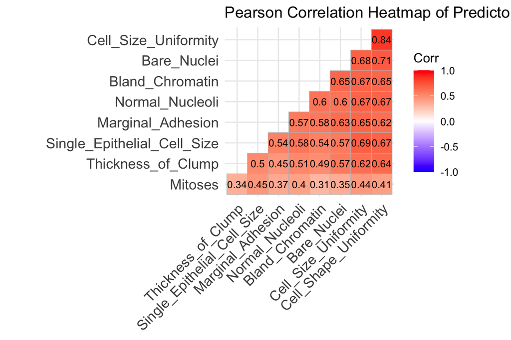

```r
# Pearson correlation matrix
corr_mat_pearson <- cor(cancer[ ,2:10], method = "pearson")

# Pearson correlation heatmap
ggcorrplot(corr_mat_pearson,
           hc.order = TRUE,
           type = "lower",
           lab = TRUE,
           lab_size = 3,
           method = "square",
           colors = c("blue", "white", "red"),
           title = "Pearson Correlation Heatmap of Predictors",
           ggtheme = theme_minimal)
```

# 3 Methodolgy & Analysis

This assignment is going to be looking at breast cancer data using principal component analysis and two clustering techniques, k-means and hierarchical. The goal is to help address the multicollinearity seen in the EDA and identify groupings within the data that correlate to patterns in the diagnosis of the tumors. In the end there will hopefully be models to help better understand the patterns in diagnosing these tumors so malignant tumors can be properly identified and treated.

## 3.1 Principal Component Analysis

A main goal of utilizing principal component analysis is reducing that variable correlation and addressing the multicollinearity we are currently seeing. This happens by transforming the data. In this case we will be undergoing a variable scanning process for all variables besides the ID variable and our outcome variable. After the transformation the PCA will be run on the data and summarized. The PCA run on the data will created a number of new variables based on information from our original variables. Then the decision will be made on how many principal components should be kept for our final analysis.

```r
# Principal Component Analysis


# Remove ID and categorical outcome variable
cancer_num <- cancer[, 2:10]

# Scale numeric variables
cancer_scaled <- scale(cancer_num)

# Run PCA
pca_model <- prcomp(cancer_scaled, center = TRUE, scale. = TRUE)

# Summary of PCA
summary(pca_model)
```

```
Importance of components:
                         PC1     PC2    PC3     PC4     PC5    PC6     PC7
Standard deviation     2.362 0.88516 0.7601 0.68262 0.65025 0.6242 0.56456
Proportion of Variance 0.620 0.08706 0.0642 0.05177 0.04698 0.0433 0.03541
Cumulative Proportion  0.620 0.70705 0.7712 0.82302 0.87000 0.9133 0.94872
                           PC8     PC9
Standard deviation     0.55359 0.39380
Proportion of Variance 0.03405 0.01723
Cumulative Proportion  0.98277 1.00000
```

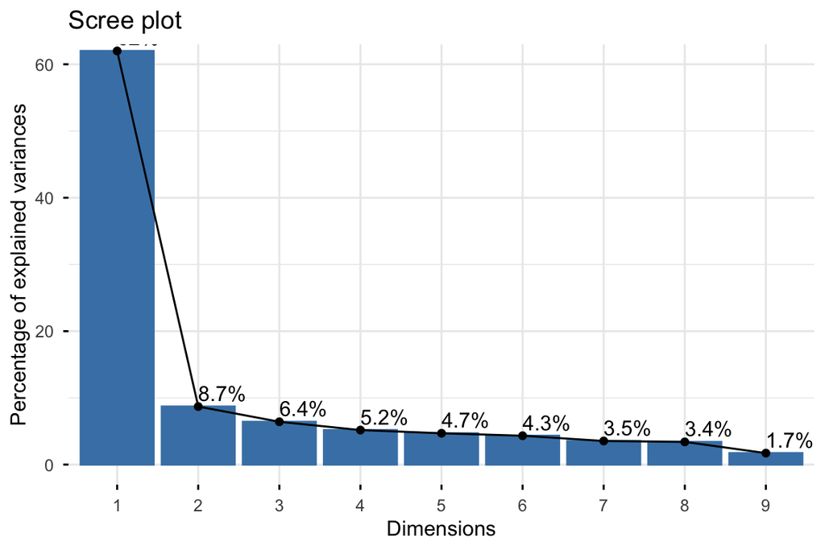

```r
# Scree plot showing % variance explained
library(factoextra)
fviz_eig(pca_model, addlabels = TRUE, ylim = c(0, 60))
```

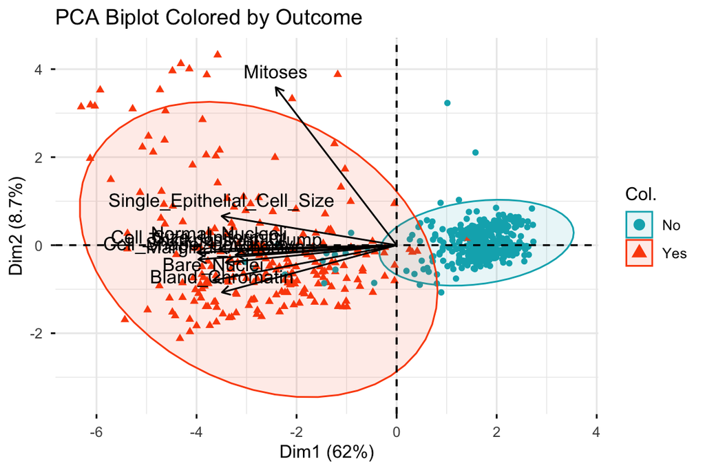

```r
# PCA biplot colored by cancer outcome
fviz_pca_biplot(pca_model,
                geom.ind = "point",
                col.ind = cancer$Outcome,
                palette = c("#00AFBB", "#FC4E07"),
                addEllipses = TRUE,
                label = "var",
                col.var = "black",
                title = "PCA Biplot Colored by Outcome")
```

```r
# Loadings (to interpret variable contributions)
pca_model$rotation
```

```
                                   PC1         PC2         PC3         PC4
Thickness_of_Clump          -0.3070514 -0.05648226 -0.81333514  0.29361318
Cell_Size_Uniformity        -0.3802675 -0.04160008 -0.06690158 -0.15686739
Cell_Shape_Uniformity       -0.3779635 -0.08220087 -0.13319051 -0.13431821
Marginal_Adhesion           -0.3259785 -0.09998840  0.47937227  0.42588885
Single_Epithelial_Cell_Size -0.3336167  0.16844948  0.02952749 -0.65196957
Bare_Nuclei                 -0.3497555 -0.20346938  0.05884037  0.32548805
Bland_Chromatin             -0.3329909 -0.27266333  0.25418507  0.07958854
Normal_Nucleoli             -0.3382363 -0.02299491  0.11012744 -0.29589192
Mitoses                     -0.2303952  0.91305830  0.07348799  0.25469213
                                    PC5         PC6          PC7         PC8
Thickness_of_Clump          -0.02299875  0.10476717 -0.224971906 -0.30438229
Cell_Size_Uniformity        -0.11617544 -0.01274432 -0.131429564  0.53517437
Cell_Shape_Uniformity       -0.07842349 -0.00402826  0.047459472  0.57797555
Marginal_Adhesion           -0.45104284  0.39479083 -0.303383463 -0.12988881
Single_Epithelial_Cell_Size -0.43265173 -0.20545376  0.012390086 -0.45058919
Bare_Nuclei                 -0.05197473 -0.22535066  0.805166225 -0.11924196
Bland_Chromatin              0.46821854 -0.57602286 -0.410456424 -0.14726621
Normal_Nucleoli              0.58462840  0.62757308  0.144263704 -0.16853379
Mitoses                      0.15961384 -0.11975359  0.009344927  0.05169848
                                     PC9
Thickness_of_Clump          -0.006355642
Cell_Size_Uniformity        -0.712206705
Cell_Shape_Uniformity        0.687117836
Marginal_Adhesion            0.065948374
Single_Epithelial_Cell_Size  0.042491971
Bare_Nuclei                 -0.104264303
Bland_Chromatin              0.051328816
Normal_Nucleoli             -0.023094382
Mitoses                      0.019912216
```

Looking at the output from the PCA there are several conclusions to be made. As to be expected in PCA the first principal component explains a majority of the data with it explaining 62% of the variance. Then moving onto the second principal component it explains 8.706% of the variance for a cumulative total of 70.705% and this gradually increases until the 9th and final principal component is reached. There is also information on how these principal components relate back to the original variables. The first principal component has negative loading for the variables cell size uniformity, cell shape uniformity, bare nuclei, and normal nucleoli. This indicates that this principal component is representative of the variables dealing will cell abnormality and that as those variables increase so does the likelihood of the tumors malignancy. Looking at the second principal component it seems to be mainly representative of the variable mitosis which is associated with the cells division. So the two principal components are representing different aspects of the cells. Considering all this information at this time it seems only utilizing the first two principal components makes the most sense.

## 3.2 Clustering

K-Means and Hierarchical Clustering methods are two methods of unsupervised learning that help identify natural groupings in data. The k-means method focuses on partitioning the data into (k) number of clusters. In this analysis there will be the plotting of a chart known as the “elbow method” that will help advise the optimal number of (k) clusters. After the optimal number of clusters have been determine a graph of the data will be showcased showing the data divided into those clusters. Moving on to the hierarchical clustering this is almost reminiscent of decision tree modeling. This process created nested trees called dendograms and groups together data based on their similarities. Despite both being clustering methods the have differences that make them unique and both beneficial so both methods will be used in the analysis for this assignment.

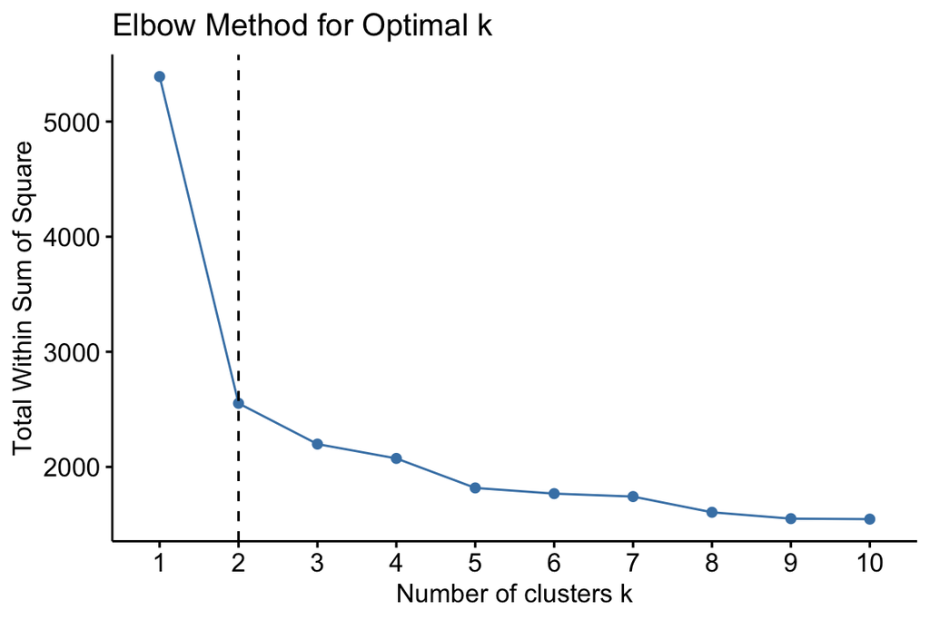

```r
# K-Means Clustering


# Determine optimal number of clusters (elbow method)
fviz_nbclust(cancer_scaled, kmeans, method = "wss") +
  geom_vline(xintercept = 2, linetype = 2) +
  labs(title = "Elbow Method for Optimal k")
```

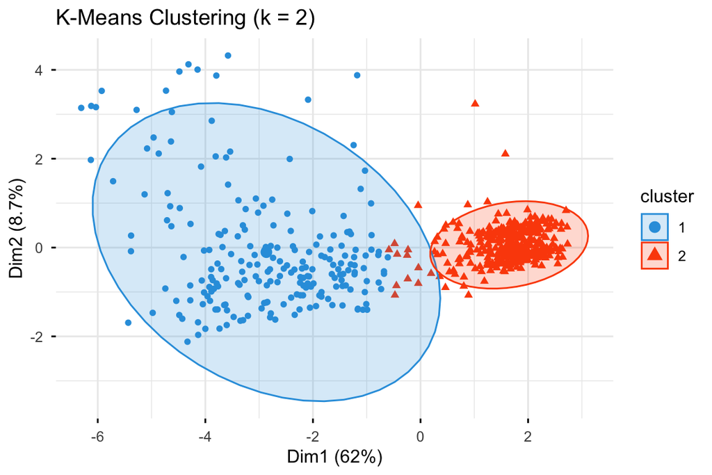

```r
# Run K-means with k = 2
set.seed(123)
kmeans_result <- kmeans(cancer_scaled, centers = 2, nstart = 25)

# Visualize K-means clusters
fviz_cluster(kmeans_result, data = cancer_scaled,
             palette = c("#2E9FDF", "#FC4E07"),
             ellipse.type = "norm",
             geom = "point",
             ggtheme = theme_minimal(),
             main = "K-Means Clustering (k = 2)")
```

```r
# Compare K-means clusters with true Outcome
table(kmeans_result$cluster, cancer$Outcome)
```

```
     No Yes
  1  12 207
  2 368  13
```

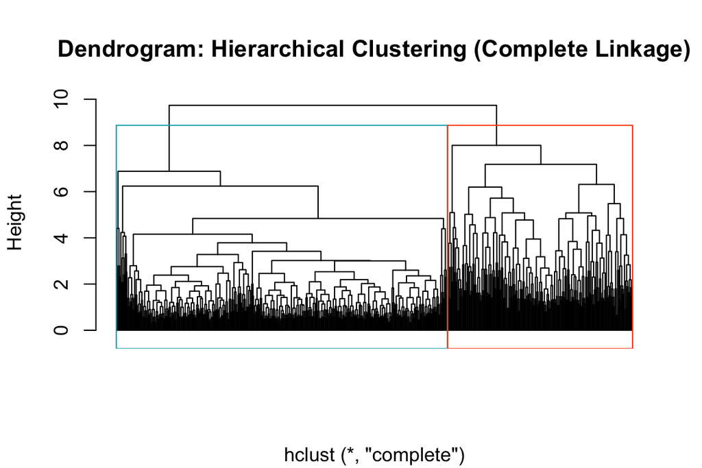

```r
# Hierarchical Clustering

# Compute distance matrix
dist_mat <- dist(cancer_scaled, method = "euclidean")

# Perform hierarchical clustering
hc <- hclust(dist_mat, method = "ward.D2")

# Plot dendrogram
# Hierarchical Clustering

# Convert scaled data to data frame
scales.hierarch <- as.data.frame(cancer_scaled)

# Compute distance matrix using Euclidean distance
distance <- dist(scales.hierarch, method = "euclidean")

# Perform hierarchical clustering using Complete Linkage
hc1 <- hclust(distance, method = "complete")

# Basic dendrogram with rectangles
plot(hc1,
     cex = 0.6,
     labels = FALSE,
     hang = -1,
     xlab = "",
     main = "Dendrogram: Hierarchical Clustering (Complete Linkage)")

# Draw rectangles for 2 clusters (you can change to 5 if desired)
rect.hclust(hc1, k = 2, border = c("#00AFBB", "#FC4E07"))
```

```r
hc_clusters <- cutree(hc, k = 2)


# Compare hierarchical clusters to true Outcome
table(hc_clusters, cancer$Outcome)
```

```
hc_clusters  No Yes
          1 358   5
          2  22 215
```

Similar to the results in the k-means clustering output the hierarchical clustering also utilizes two groups. However, there is a switch in this cluster compared to the k-means. Instead of the malignant tumors being mainly captured in the first cluster we see the benign tumors being captured in this cluster. The first cluster has 358 benign cases and 5 malignant, while the second cluster has 22 benign cases and 215 malignant cases. Again, there is some misclassification but overall the amount of misclassification is not concerning considering the size of the data set. Overall, this hierarchical clustering model seems to be very strong just like the k-means model.

# 4 Results & Conclusions

This assignment showcased the benefits of using these unsupervised learning methods in addressing data sets with multicollinearity issues. The PCA analysis allowed for over 70% of the total variance to be explained by the two principal components, and these components mainly addressed cell abnormality and behavior. This was able to indicate what important tumor diagnosis factors are. Moving on to the clustering methods both the k-means and hierarchical recommended 2 clusters both of which did a good job at classifying malignant and benign tumors, despite a few misclassifications in both models. Overall, there was strong consistency in tumor classification across the three different unsupervised learning methods. Next week the assignment will be continued and expanded upon with Local Outlier Facotr (LOF) and the building of binary classification models.